# Определение стоимости автомобиля - git

## Подготовка данных

```python
from sklearn.compose import ColumnTransformer
from sklearn.pipeline import Pipeline
from sklearn.model_selection import train_test_split, cross_val_score, GridSearchCV
import numpy as np
import pandas as pd
import time
import shap
from termcolor import colored # цвет
from matplotlib import pyplot as plt # графики
import seaborn as sns # графики
from scipy.stats import pearsonr
import phik # расчет коэффициентов корреляции
import copy

# загружаем классы для подготовки данных
from sklearn.preprocessing import (
    OneHotEncoder
    ,OrdinalEncoder
    ,StandardScaler
    ,MinMaxScaler
    ,RobustScaler
    ,PolynomialFeatures
)

from sklearn.compose import ColumnTransformer
from sklearn.preprocessing import LabelEncoder
from sklearn.cluster import KMeans # метод кластеризации
from sklearn.impute import SimpleImputer # загружаем класс для работы с пропусками
from sklearn.model_selection import RandomizedSearchCV, GridSearchCV, train_test_split # импортируем класс RandomizedSearchCV

# загружаем нужные модели
from sklearn.linear_model import LogisticRegression, LinearRegression
from sklearn.neighbors import KNeighborsClassifier
from sklearn.tree import DecisionTreeClassifier
from sklearn.svm import SVC
from lightgbm import LGBMRegressor

# загружаем класс pipeline
from sklearn.pipeline import Pipeline

# анализ эффективности модели
from sklearn.metrics import (
 roc_auc_score # загружаем функцию для работы с метриками
 ,mean_absolute_error # расчет ошибки
 ,r2_score # расчет ошибки
 ,mean_squared_error # импорт MSE для RMSE аргумент функции squared = False
 ,confusion_matrix # матрица ошибок (первый/второй год)
 ,accuracy_score # проверка ошибки логистической регрессии
 ,recall_score # ошибки второго рода
 ,precision_score # Ошибки первого рода
)
from sklearn.metrics import make_scorer
```

```python
data = pd.read_csv('autos.csv')
```

```python
# Изменение толщины текста
def big_bold_text(text):
    return colored(text, attrs=['bold'])
```

```python
#Создадим словарь соответствия фрейма и его имени
dictionary_with_frames ={
    'data': data
}
```

```python
for row in dictionary_with_frames:
    dictionary_with_frames[row].columns = dictionary_with_frames[row].columns.str.lower()
    dictionary_with_frames[row].columns = dictionary_with_frames[row].columns.str.replace(' ', '_', regex=True)
```

**Протестируем данные на дубликаты, пропуски и правильность типов данных**

```python
#Функция тестировани данных
def test_df (dictionary_with_frames_col):
    for row in dictionary_with_frames_col:
        print(big_bold_text('Таблица: '),row)
        print(big_bold_text('Количество дубликатов: '),dictionary_with_frames[row].duplicated().sum())
        if dictionary_with_frames[row].duplicated().sum()>0:
            print('')
            print(big_bold_text('Строки с дубликатами:'))
            display(dictionary_with_frames[row].loc[dictionary_with_frames[row].duplicated()==True])
        print('')
        print(big_bold_text('Информация по таблице\n'))
        dictionary_with_frames[row].info()
        print('')
        print(big_bold_text('Количество пропусков:\n'))
        print(dictionary_with_frames[row].isna().sum())
        print('')
        print(big_bold_text('Вывод первых 5 строк из таблицы\n'))
        display(dictionary_with_frames[row].head(5))
        print(big_bold_text('_____________________________________________________________________________________________________'))
        print('')
test_df(dictionary_with_frames)
```

```
Таблица:  data
Количество дубликатов:  4

Строки с дубликатами:
```

|  | datecrawled | price | vehicletype | registrationyear | gearbox | power | model | kilometer | registrationmonth | fueltype | brand | repaired | datecreated | numberofpictures | postalcode | lastseen |
| --- | --- | --- | --- | --- | --- | --- | --- | --- | --- | --- | --- | --- | --- | --- | --- | --- |
| 171088 | 2016-03-08 18:42:48 | 1799 | coupe | 1999 | auto | 193 | clk | 20000 | 7 | petrol | mercedes_benz | no | 2016-03-08 00:00:00 | 0 | 89518 | 2016-03-09 09:46:57 |
| 231258 | 2016-03-28 00:56:10 | 1000 | small | 2002 | manual | 83 | other | 150000 | 1 | petrol | suzuki | no | 2016-03-28 00:00:00 | 0 | 66589 | 2016-03-28 08:46:21 |
| 258109 | 2016-04-03 09:01:15 | 4699 | coupe | 2003 | auto | 218 | clk | 125000 | 6 | petrol | mercedes_benz | yes | 2016-04-03 00:00:00 | 0 | 75196 | 2016-04-07 09:44:54 |
| 325651 | 2016-03-18 18:46:15 | 1999 | wagon | 2001 | manual | 131 | passat | 150000 | 7 | gasoline | volkswagen | no | 2016-03-18 00:00:00 | 0 | 36391 | 2016-03-18 18:46:15 |

```
Информация по таблице

<class 'pandas.core.frame.DataFrame'>
RangeIndex: 354369 entries, 0 to 354368
Data columns (total 16 columns):
 #   Column             Non-Null Count   Dtype
---  ------             --------------   -----
 0   datecrawled        354369 non-null  object
 1   price              354369 non-null  int64
 2   vehicletype        316879 non-null  object
 3   registrationyear   354369 non-null  int64
 4   gearbox            334536 non-null  object
 5   power              354369 non-null  int64
 6   model              334664 non-null  object
 7   kilometer          354369 non-null  int64
 8   registrationmonth  354369 non-null  int64
 9   fueltype           321474 non-null  object
 10  brand              354369 non-null  object
 11  repaired           283215 non-null  object
 12  datecreated        354369 non-null  object
 13  numberofpictures   354369 non-null  int64
 14  postalcode         354369 non-null  int64
 15  lastseen           354369 non-null  object
dtypes: int64(7), object(9)
memory usage: 43.3+ MB

Количество пропусков:

datecrawled              0
price                    0
vehicletype          37490
registrationyear         0
gearbox              19833
power                    0
model                19705
kilometer                0
registrationmonth        0
fueltype             32895
brand                    0
repaired             71154
datecreated              0
numberofpictures         0
postalcode               0
lastseen                 0
dtype: int64

Вывод первых 5 строк из таблицы
```

|  | datecrawled | price | vehicletype | registrationyear | gearbox | power | model | kilometer | registrationmonth | fueltype | brand | repaired | datecreated | numberofpictures | postalcode | lastseen |
| --- | --- | --- | --- | --- | --- | --- | --- | --- | --- | --- | --- | --- | --- | --- | --- | --- |
| 0 | 2016-03-24 11:52:17 | 480 | NaN | 1993 | manual | 0 | golf | 150000 | 0 | petrol | volkswagen | NaN | 2016-03-24 00:00:00 | 0 | 70435 | 2016-04-07 03:16:57 |
| 1 | 2016-03-24 10:58:45 | 18300 | coupe | 2011 | manual | 190 | NaN | 125000 | 5 | gasoline | audi | yes | 2016-03-24 00:00:00 | 0 | 66954 | 2016-04-07 01:46:50 |
| 2 | 2016-03-14 12:52:21 | 9800 | suv | 2004 | auto | 163 | grand | 125000 | 8 | gasoline | jeep | NaN | 2016-03-14 00:00:00 | 0 | 90480 | 2016-04-05 12:47:46 |
| 3 | 2016-03-17 16:54:04 | 1500 | small | 2001 | manual | 75 | golf | 150000 | 6 | petrol | volkswagen | no | 2016-03-17 00:00:00 | 0 | 91074 | 2016-03-17 17:40:17 |
| 4 | 2016-03-31 17:25:20 | 3600 | small | 2008 | manual | 69 | fabia | 90000 | 7 | gasoline | skoda | no | 2016-03-31 00:00:00 | 0 | 60437 | 2016-04-06 10:17:21 |

```
_____________________________________________________________________________________________________
```

```python
data['datecrawled'] = pd.to_datetime(data['datecrawled'])
data['datecreated'] = pd.to_datetime(data['datecreated'])
data['lastseen'] = pd.to_datetime(data['lastseen'])
```

```python
data.info()
```

```
<class 'pandas.core.frame.DataFrame'>
RangeIndex: 354369 entries, 0 to 354368
Data columns (total 16 columns):
 #   Column             Non-Null Count   Dtype
---  ------             --------------   -----
 0   datecrawled        354369 non-null  datetime64[ns]
 1   price              354369 non-null  int64
 2   vehicletype        316879 non-null  object
 3   registrationyear   354369 non-null  int64
 4   gearbox            334536 non-null  object
 5   power              354369 non-null  int64
 6   model              334664 non-null  object
 7   kilometer          354369 non-null  int64
 8   registrationmonth  354369 non-null  int64
 9   fueltype           321474 non-null  object
 10  brand              354369 non-null  object
 11  repaired           283215 non-null  object
 12  datecreated        354369 non-null  datetime64[ns]
 13  numberofpictures   354369 non-null  int64
 14  postalcode         354369 non-null  int64
 15  lastseen           354369 non-null  datetime64[ns]
dtypes: datetime64[ns](3), int64(7), object(6)
memory usage: 43.3+ MB
```

**Проведем анализ категориальных данных**

```
Таблица:  data
Пропущен столбец datecrawled (уникальных значений: 271174)
Категориальный признак:  vehicletype
```

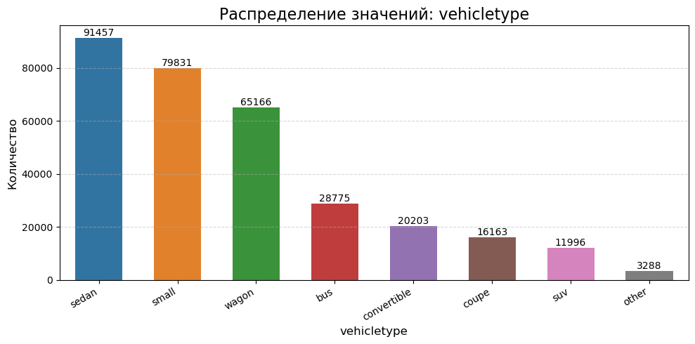

```
Категориальный признак:  gearbox
```

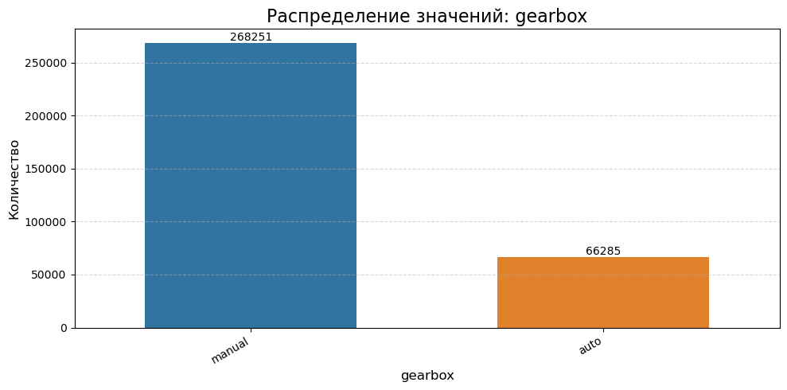

```
Пропущен столбец model (уникальных значений: 251)
Категориальный признак:  fueltype
```

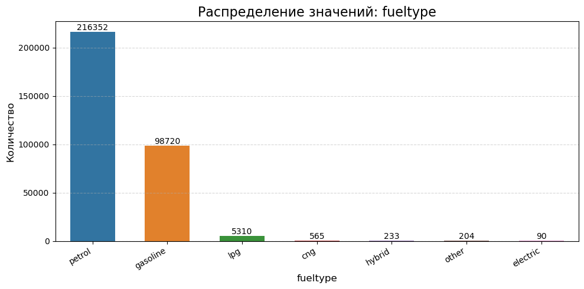

```
Пропущен столбец brand (уникальных значений: 40)
Категориальный признак:  repaired
```

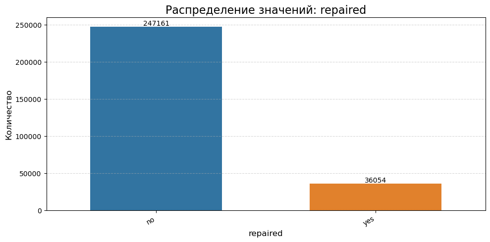

```
Пропущен столбец datecreated (уникальных значений: 109)
Пропущен столбец lastseen (уникальных значений: 179150)
```

```python
MAX_CATEGORIES = 30  # Максимальное количество уникальных значений для отображения

for table_name, df in dictionary_with_frames.items():
    print(big_bold_text('Таблица: '), table_name)

    cat_columns = df.select_dtypes(exclude=np.number).columns

    for col in cat_columns:
        n_unique = df[col].nunique(dropna=False)

        # Пропускаем слишком разнообразные столбцы
        if n_unique > MAX_CATEGORIES:
            print(f"Пропущен столбец {col} (уникальных значений: {n_unique})")
            continue

        print(big_bold_text('Категориальный признак: '), col)

        value_counts = df[col].value_counts(dropna=False).reset_index()
        value_counts.columns = [col, 'count']

        plt.figure(figsize=(10, 5))
        ax = sns.barplot(data=value_counts, x=col, y='count', hue=col, dodge=False, legend=False, width=0.6)
        ax.set_title(f'Распределение значений: {col}', fontsize=16)
        ax.set_xlabel(col, fontsize=12)
        ax.set_ylabel('Количество', fontsize=12)
        plt.xticks(rotation=30, ha='right')
        plt.grid(axis='y', linestyle='--', alpha=0.5)

        for p in ax.patches:
            height = int(p.get_height())
            ax.text(p.get_x() + p.get_width() / 2., height + 0.5, str(height),
                    ha='center', va='bottom', fontsize=10, color='black')

        plt.tight_layout()
        plt.show()
```

**Построим графики распределения числовых данных**

```
Таблица:  data
Наименование столбца:  price
```

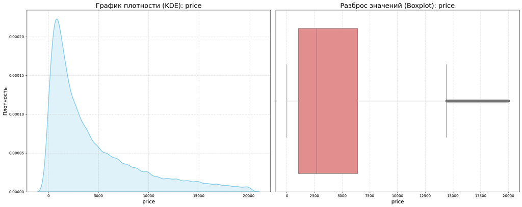

```
Наименование столбца:  registrationyear
```

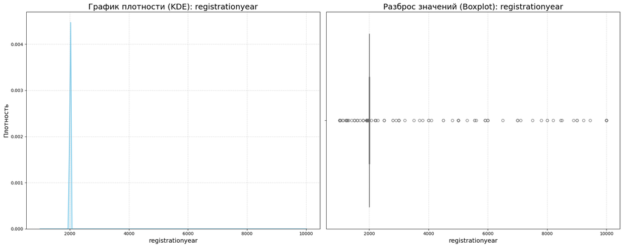

```
Наименование столбца:  power
```

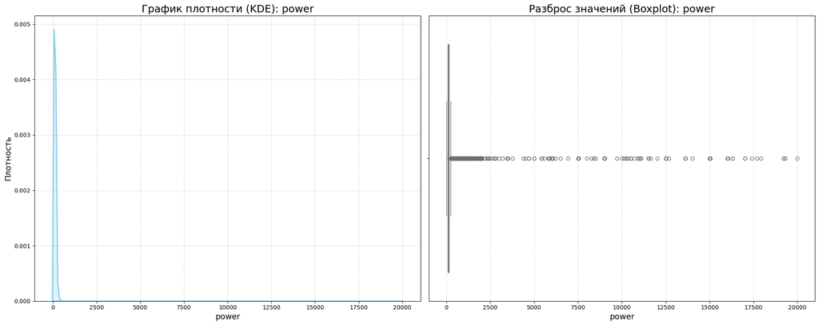

```
Наименование столбца:  kilometer
```

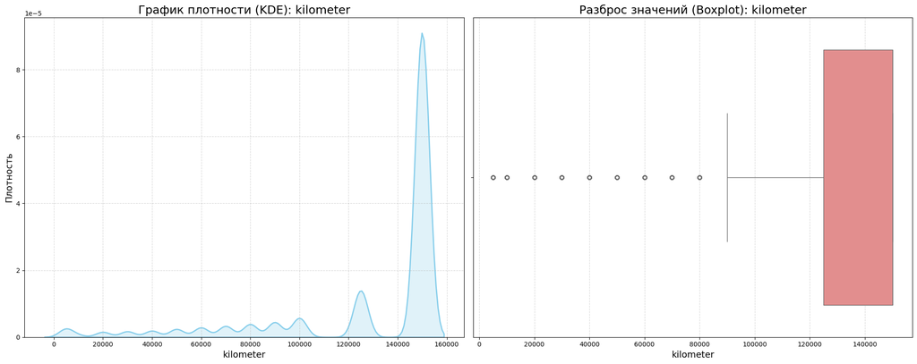

```
Наименование столбца:  registrationmonth
```

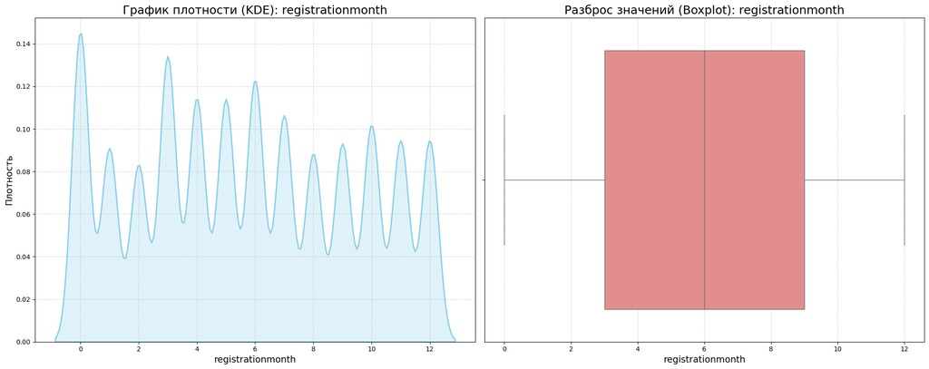

```
Наименование столбца:  numberofpictures
```

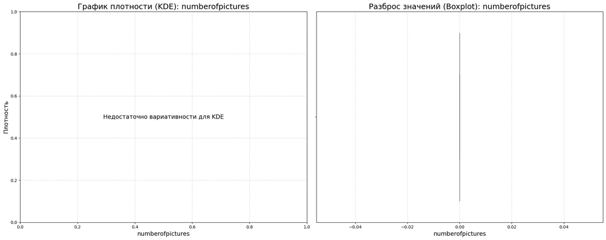

```
Наименование столбца:  postalcode
```

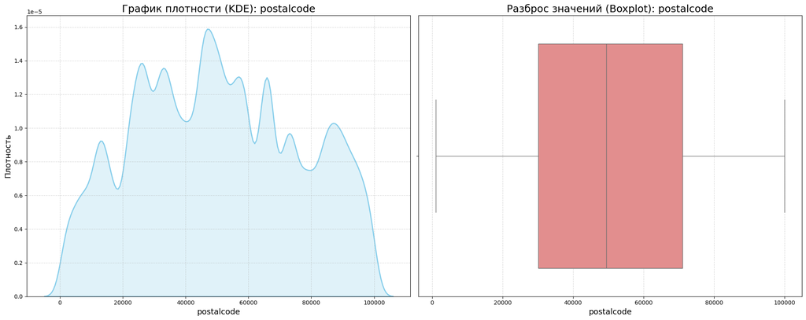

```python
for table_name, df in dictionary_with_frames.items():
    print(big_bold_text('Таблица: '), table_name)

    numeric_columns = df.select_dtypes(include='number').columns

    for col in numeric_columns:
        print(big_bold_text('Наименование столбца: '), col)

        fig, axes = plt.subplots(1, 2, figsize=(20, 8))

        # --- KDE Plot ---
        if df[col].nunique() > 1:
            sns.kdeplot(df[col].dropna(), ax=axes[0], fill=True, color='skyblue', linewidth=2)
        else:
            axes[0].text(0.5, 0.5, 'Недостаточно вариативности для KDE',
                         horizontalalignment='center',
                         verticalalignment='center',
                         fontsize=14,
                         transform=axes[0].transAxes)

        axes[0].set_title(f'График плотности (KDE): {col}', fontsize=18)
        axes[0].set_xlabel(col, fontsize=14)
        axes[0].set_ylabel('Плотность', fontsize=14)
        axes[0].grid(True, linestyle='--', alpha=0.5)

        # --- Boxplot ---
        sns.boxplot(x=df[col], ax=axes[1], color='lightcoral', orient='h')
        axes[1].set_title(f'Разброс значений (Boxplot): {col}', fontsize=18)
        axes[1].set_xlabel(col, fontsize=14)
        axes[1].grid(True, axis='x', linestyle='--', alpha=0.5)

        plt.tight_layout()
        plt.show()
```

```python
data.describe()
```

|  | price | registrationyear | power | kilometer | registrationmonth | numberofpictures | postalcode |
| --- | --- | --- | --- | --- | --- | --- | --- |
| count | 354369.000000 | 354369.000000 | 354369.000000 | 354369.000000 | 354369.000000 | 354369.0 | 354369.000000 |
| mean | 4416.656776 | 2004.234448 | 110.094337 | 128211.172535 | 5.714645 | 0.0 | 50508.689087 |
| std | 4514.158514 | 90.227958 | 189.850405 | 37905.341530 | 3.726421 | 0.0 | 25783.096248 |
| min | 0.000000 | 1000.000000 | 0.000000 | 5000.000000 | 0.000000 | 0.0 | 1067.000000 |
| 25% | 1050.000000 | 1999.000000 | 69.000000 | 125000.000000 | 3.000000 | 0.0 | 30165.000000 |
| 50% | 2700.000000 | 2003.000000 | 105.000000 | 150000.000000 | 6.000000 | 0.0 | 49413.000000 |
| 75% | 6400.000000 | 2008.000000 | 143.000000 | 150000.000000 | 9.000000 | 0.0 | 71083.000000 |
| max | 20000.000000 | 9999.000000 | 20000.000000 | 150000.000000 | 12.000000 | 0.0 | 99998.000000 |

Видно, что есть цены 0 и ниже 100 евро за машину, что маловероятно. В столбцах registrationyear, power есть аномальные значения В столбцах vehicletype, gearbox, model, fueltype, notrepaired заполним nan unknown

### Данные изучены, начнем предобработку данных

Удалим дубликаты

```python
data = data.drop_duplicates().reset_index(drop=True)
```

```python
data.columns
```

```
Index(['datecrawled', 'price', 'vehicletype', 'registrationyear', 'gearbox',
       'power', 'model', 'kilometer', 'registrationmonth', 'fueltype', 'brand',
       'repaired', 'datecreated', 'numberofpictures', 'postalcode',
       'lastseen'],
      dtype='object')
```

Удалим столбцы, которые не влияют на предсказание целевого признака

```python
columns_to_drop = [
    'datecrawled',
    'registrationmonth',
    'numberofpictures',
    'lastseen',
    'datecreated',
    'numberofpictures',
    'postalcode'
]
data = data.drop(columns_to_drop, axis=1)
```

Обработка пропусков

```python
def dropnull(data):
    nulls = data.isnull().sum()
    data_null = pd.DataFrame({
        'quantity': nulls,
        'percentage': round(nulls / len(data) * 100, 1)
    })
    data_null = data_null.query('percentage != 0').sort_values(by='percentage', ascending=False)
    data_null.columns = pd.MultiIndex.from_tuples(
        zip(['Количество пропусков в столбцах', 'Количество пропусков в столбцах'], data_null.columns)
    )
    if len(data_null) == 0:
        return 'Пропусков нет'
    return data_null
```

```python
dropnull(data)
```

|  | Количество пропусков в столбцах quantity | Количество пропусков в столбцах percentage |
| --- | --- | --- |
| repaired | 71154 | 20.1 |
| vehicletype | 37490 | 10.6 |
| fueltype | 32895 | 9.3 |
| gearbox | 19833 | 5.6 |
| model | 19705 | 5.6 |

**repaired** в данном столбце много пропусков, просто таку удалить нельзя. Заменим пропуски на значения **unknown**

```python
data['repaired'] = data['repaired'].fillna('unknown')
dropnull(data)
```

|  | Количество пропусков в столбцах quantity | Количество пропусков в столбцах percentage |
| --- | --- | --- |
| vehicletype | 37490 | 10.6 |
| fueltype | 32895 | 9.3 |
| gearbox | 19833 | 5.6 |
| model | 19705 | 5.6 |

Отнесем пропуски столбце **fueltype** к значению **other**

```python
data['fueltype'] = data['fueltype'].fillna('other')
dropnull(data)
```

|  | Количество пропусков в столбцах quantity | Количество пропусков в столбцах percentage |
| --- | --- | --- |
| vehicletype | 37490 | 10.6 |
| gearbox | 19833 | 5.6 |
| model | 19705 | 5.6 |

Сделаем аналогичное действие со столбцом **vehicletype**

```python
data['vehicletype'] = data['vehicletype'].fillna('other')
dropnull(data)
```

|  | Количество пропусков в столбцах quantity | Количество пропусков в столбцах percentage |
| --- | --- | --- |
| gearbox | 19833 | 5.6 |
| model | 19705 | 5.6 |

Для столбца присвоим пропускам категорию **unknown**

```python
data['gearbox'] = data['gearbox'].fillna('unknown')
dropnull(data)
```

|  | Количество пропусков в столбцах quantity | Количество пропусков в столбцах percentage |
| --- | --- | --- |
| model | 19705 | 5.6 |

Аналогично для столбца **model** пропускам в fueltype и vehicletype, можно отнести пропуски в группу **other**

```python
data['model'] = data['model'].fillna('other')
dropnull(data)
```

```
'Пропусков нет'
```

Все пропуски в текущем DF отработаны. Пропусков нет

Обработаем выбросы. Начнем со столбца **price**

[figure not shown]

Возьмем минимальную стоимость авто 900 долларов и отфильтруем наш df

```python
data = data.loc[data['price']>=900].reset_index(drop=True)
```

Отберем логичную дату регистрации авто

```python
data = data.loc[(data['registrationyear']>=1900)&((data['registrationyear']<=2016))].reset_index(drop=True)
```

Отработаем выбросы в столбце **power**

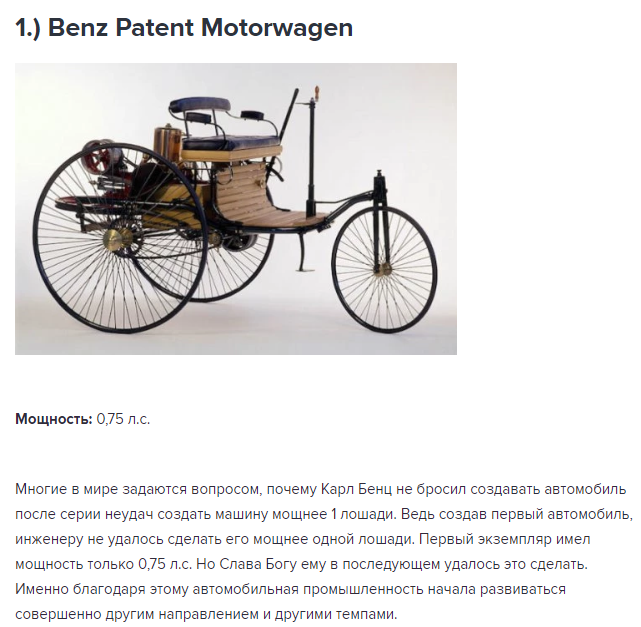

[figure not shown]

Сделаем диапазон значений **power** пределах от **0,75 до 1000**

```python
data = data.loc[(data['power']>=0.75)&((data['power']<=1000))].reset_index(drop=True)
```

C данными по пробегу все хорошо, никаких изменений вносить не будем

**Вывод:**

1. Данные проанализировал
2. Выбросы и дубликаты удалил
3. Пропуски обработал, заменил либо на категорию other, либо прописал ззначение unknown

## Обучение моделей

```python
# RMSE метрика
def rmse(y_true, y_pred):
    return np.sqrt(mean_squared_error(y_true, y_pred))

rmse_scorer = make_scorer(rmse, greater_is_better=False)

# Подготовка данных
categorical_features_ordinal = ['model']
categorical_features_ohe = ['vehicletype', 'gearbox', 'fueltype', 'brand', 'repaired']
numerical_features = list(set(data.columns) - set(categorical_features_ordinal) - set(categorical_features_ohe) - {'price'})

# Разделение на выборки
features = data.drop("price", axis=1)
target = data["price"]

# Отделение тестовой выборки
features_train_valid, features_test, target_train_valid, target_test = train_test_split(features, target, test_size=0.2, random_state=42)

# Отделение обучающей и валидационной выборки
features_train, features_valid, target_train, target_valid = train_test_split(features_train_valid, target_train_valid, test_size=0.25, random_state=42)

# Предобработка данных
preprocessor = ColumnTransformer(
    transformers=[
        ('ordinal', OrdinalEncoder(handle_unknown='use_encoded_value', unknown_value=-1), categorical_features_ordinal),
        ('ohe', OneHotEncoder(handle_unknown='ignore'), categorical_features_ohe),
        ('scaler', StandardScaler(), numerical_features)
    ])

# Линейная регрессия
lr_pipeline = Pipeline(steps=[
    ('preprocessor', preprocessor),
    ('regressor', LinearRegression())
])

lr_params = {'regressor__fit_intercept': [True, False]}
grid_lr = GridSearchCV(lr_pipeline, lr_params, cv=4, scoring=rmse_scorer, verbose=False, refit=True)

start_time = time.time()
grid_lr.fit(features_train, target_train)
lr_train_time = time.time() - start_time

lr_best_model = grid_lr.best_estimator_
lr_pred_train = lr_best_model.predict(features_train)
lr_pred_valid = lr_best_model.predict(features_valid)
lr_pred_test = lr_best_model.predict(features_test)

lr_rmse_train = rmse(target_train, lr_pred_train)
lr_rmse_valid = rmse(target_valid, lr_pred_valid)
lr_rmse_test = rmse(target_test, lr_pred_test)

start_time = time.time()
_ = lr_best_model.predict(features_valid)  # Прогрев
lr_valid_predict_time = time.time() - start_time

start_time = time.time()
_ = lr_best_model.predict(features_test)  # Прогрев
lr_test_predict_time = time.time() - start_time

# LightGBM
lgb_pipeline = Pipeline(steps=[
    ('preprocessor', preprocessor),
    ('regressor', LGBMRegressor(random_state=42))
])

lgb_params = {
    'regressor__n_estimators': [100, 200],
    'regressor__max_depth': [10, 12]
}

grid_lgb = GridSearchCV(lgb_pipeline, lgb_params, cv=4, scoring=rmse_scorer, verbose=False, refit=True)

start_time = time.time()
grid_lgb.fit(features_train, target_train)
lgb_train_time = time.time() - start_time

lgb_best_model = grid_lgb.best_estimator_
lgb_pred_train = lgb_best_model.predict(features_train)
lgb_pred_valid = lgb_best_model.predict(features_valid)
lgb_pred_test = lgb_best_model.predict(features_test)

lgb_rmse_train = rmse(target_train, lgb_pred_train)
lgb_rmse_valid = rmse(target_valid, lgb_pred_valid)
lgb_rmse_test = rmse(target_test, lgb_pred_test)

start_time = time.time()
_ = lgb_best_model.predict(features_valid)  # Прогрев
lgb_valid_predict_time = time.time() - start_time

start_time = time.time()
_ = lgb_best_model.predict(features_test)  # Прогрев
lgb_test_predict_time = time.time() - start_time

# Вывод результатов
print("Модель: Linear Regression")
print(f"RMSE (обучение): {lr_rmse_train:.4f}")
print(f"RMSE (валидация): {lr_rmse_valid:.4f}")
print(f"RMSE (тест): {lr_rmse_test:.4f}")
print(f"Время обучения: {lr_train_time:.4f} сек")
print(f"Время предсказания (валидная выборка): {lr_valid_predict_time:.4f} сек")
print(f"Время предсказания (тестовая выборка): {lr_test_predict_time:.4f} сек")
print()

print("Модель: LightGBM")
print(f"RMSE (обучение): {lgb_rmse_train:.4f}")
print(f"RMSE (валидация): {lgb_rmse_valid:.4f}")
print(f"RMSE (тест): {lgb_rmse_test:.4f}")
print(f"Время обучения: {lgb_train_time:.4f} сек")
print(f"Время предсказания (валидная выборка): {lgb_valid_predict_time:.4f} сек")
print(f"Время предсказания (тестовая выборка): {lgb_test_predict_time:.4f} сек")
```

```
Модель: Linear Regression
RMSE (обучение): 2844.3823
RMSE (валидация): 2846.7487
RMSE (тест): 2866.8032
Время обучения: 26.9456 сек
Время предсказания (валидная выборка): 0.0910 сек
Время предсказания (тестовая выборка): 0.0885 сек

Модель: LightGBM
RMSE (обучение): 1615.3529
RMSE (валидация): 1695.2943
RMSE (тест): 1680.7255
Время обучения: 80.5018 сек
Время предсказания (валидная выборка): 0.8046 сек
Время предсказания (тестовая выборка): 0.7986 сек
```

**Комментари**

На тестовой выборке следует оценивать только одну модель — ту, которая показала наилучший результат по метрике RMSE. Сравнение моделей выполняется исключительно на этапе кросс-валидации (`grid.best_score_`) или на валидационной выборке. Вызовы `.predict(X_test)` на этапах обучения, подбора гиперпараметров и анализа моделей недопустимы. Этот метод используется только на этапе финальной проверки выбранной лучшей модели на тестовой выборке.

Преобразуем категориальные и числовые данные в нужный формат для обучения

```python
# #Преобразуем столбец model
# encoder = OrdinalEncoder()
# encoder.fit(data[['model']])
# data['model'] = encoder.transform(data[['model']])
```

```python
# #Преобразуем остальные категории в числа
# one_hot_list = ['vehicletype','gearbox', 'fueltype', 'brand', 'repaired']
# df = data.copy()
# tenure_one_hot = pd.get_dummies(df[one_hot_list], drop_first=True)
# df = df.drop(one_hot_list,axis = 1)
# df = df.join(tenure_one_hot, how='left')
# df
```

```python
# features = df.drop("price", axis=1)
# target = df["price"]
```

```python
# #Отделение тестовой части
# x, features_test, y, target_test = train_test_split(features, target, test_size=0.2, train_size=0.8)
```

```python
# #Отделения валидационной и обучающей выборки
# features_train, features_valid, target_train, target_valid = train_test_split(x, y, test_size = 0.25, train_size =0.75)
```

```python
# #Скалирование
# scaler = StandardScaler()
# scaler.fit(features_train)
# features_train_scaled = scaler.transform(features_train)
# features_valid_scaled = scaler.transform(features_valid)
# features_test_scaled = scaler.transform(features_test)
```

```python
# #Преобразуем nparray в dataframe
# def nptodf(data, ind, column):
#     frame = pd.DataFrame(data, index = ind.index, columns = column.columns)
#     return frame
# features_train_scaled = nptodf(features_train_scaled, target_train, features)
# features_valid_scaled = nptodf(features_valid_scaled, target_valid, features)
# features_test_scaled = nptodf(features_test_scaled, target_test, features)
```

**Обучение модели**

### Линейная регрессия

```python
# def rmse(predict, actual):
#     predict = np.array(predict)
#     actual = np.array(actual)

#     distance = predict - actual

#     square_distance = distance ** 2

#     mean_square_distance = square_distance.mean()

#     score = np.sqrt(mean_square_distance)

#     return score

# rmse_score = make_scorer(rmse, greater_is_better = False)
```

```python
# %%time
# model_lr = LinearRegression().fit(features_train_scaled, target_train)
# lr_pred = model_lr.predict(features_valid_scaled)
# rmse_lr = np.sqrt(mean_squared_error(target_valid, lr_pred))
# print('RMSE LinearRegression:', rmse_lr)
```

```python
# %%time
# parameters = {'fit_intercept':[True,False], 'normalize':[True,False], 'copy_X':[True, False]}
# grid = GridSearchCV(model_lr,parameters, cv=4, scoring = rmse_score, verbose=False)
# grid.fit(features_train_scaled, target_train)
# grid.best_params_
```

```python
# %%time
# lr_tuned = LinearRegression(**grid.best_params_).fit(features_train_scaled, target_train)
```

```python
# %%time
# lr_pred = lr_tuned.predict(features_valid_scaled)
```

```python
# rmse_lr_tuned = np.sqrt(mean_squared_error(target_valid, lr_pred))
# print("LinearRegression RMSE: %.2f" % rmse_lr_tuned)
```

### Метод LightGBM

```python
# %%time
# lgb_model = LGBMRegressor().fit(features_train_scaled, target_train)
# y_pred = lgb_model.predict(features_valid_scaled)
# rmse_lgbm = np.sqrt(mean_squared_error(target_valid, y_pred))
# print('RMSE LightGBM:', rmse_lgbm)
```

```python
# %%time
# lgbm_params = {"n_estimators": [1000, 1200],
#                "max_depth": [12, 14]
#               }

# lgbm_cv_model = GridSearchCV(lgb_model,
#                              lgbm_params,
#                              cv=4,
#                              scoring = rmse,
#                              n_jobs=-1,
#                              verbose=False).fit(features_train_scaled, target_train)

# lgbm_cv_model.best_params_
```

```python
# %%time
# lgbm_tuned = LGBMRegressor(**lgbm_cv_model.best_params_).fit(features_train_scaled, target_train)
```

```python
# %%time
# y_pred = lgbm_tuned.predict(features_valid_scaled)
```

```python
# rmse_lgb = np.sqrt(mean_squared_error(target_valid, y_pred))
# print("RMSE: %.2f" % rmse_lgb)
```

## Анализ

Для предсказания ипользовал 2 модели. Одна классическая модель линейной регрессии, другая модель LGBMRegressor

Нам удалось достигнуть желаемого результата для модели LGBMRegressor значение RMSE < 2500. Сейчас он равен 1680.7255

## ВЫВОД

1. Для разработки модели был проанализирован входной DF.
2. Были удалены выбросы, дубликаты, заменены пропуски на нужные значения. Конечный DF немного сократился относительно входного
3. Для модели были отобраны только те параметры (столбцы), которые могут повлиять на предсказание целевого признака. Ненужные параметры были исключены
4. Было обучено 2 модели. LinearRegression и LGBMRegressor. Данные были разбиты на три выборки. Тренировочная, Валидная и Тестовая. Было произведено обучени и подбор целеых параметров. Лучше всего себя показала модель. LGBMRegressor

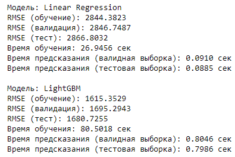

**Резюме для заказчика:**

1. Если важная скорость и есть большая ограниченность по вычислительным ресурсам, то можно использовать LinearRegression, однако необходимо докрутить показатель RMSE до целевого.
2. Если у заказчика модели есть большой ресур для того, чтобы данная модель крутилась и предсказывала, то я бы рекомендовал использовать LGBMRegressor. Плсюс, если у закачика нет потребности предсказывать супер быстро (как на фондовом рынке, дорога каждая милисекунда)
3. Необходимо запросить у заказчика дополнительный финансовый и временной ресурс, чтобы исследовать другие модели для предсказания